# Analysis of Dataset D

2025-02-06

```r
#all the necessary libraries
library(readxl)
library(lubridate)
library(dplyr)
library(stringr)
library(data.table)
library(naniar)
library(ggplot2)
library(openxlsx)
library(patchwork)
```

## Dimension of the dataset

```r
cat("The dataset has", nrow(dataset), "rows and", ncol(dataset), "columns.\n")
```

```
## The dataset has 1117 rows and 231 columns.
```

## Structure of the dataset

```r
str(dataset)
```

## The Variables

### Info about Other Projects (useless)

- **PROJECT 1 (immunogram):** Participation in immunogram project (likely a binary flag).
- **PROJECT 2 (dNLR prebaseline DELTA):** Participation in project regarding delta neutrophil-to-lymphocyte ratio before baseline.
- **PROJECT 3 (dNLR score profiles):** Participation in project related to dNLR score profiles.
- **PROJECT 4 (AI + IO):** Participation in artificial intelligence and immuno-oncology project.

### Personal Info about the Patients

- **Hospital:** Code or name of the treating hospital.
- **ID (Clinic Number):** Patient’s clinical identification number.
- **Date of birth:** Patient’s date of birth.
- **Sex:** Biological sex of the patient.
- **Smoking:** Patient’s smoking history (e.g., current, former).
- **Smoker:** Whether the patient has ever smoked (yes/no).
- **PY:** Pack-years smoked.
- **KG:** Weight in kilograms.
- **HEIGHT:** Height in centimeters.
- **BMI:** Body Mass Index.

### Diagnosis

- **Date of diagnosis:** Initial diagnosis date of lung cancer.
- **T:** Tumor size/staging (TNM system).
- **N:** Lymph node involvement (TNM system).
- **M:** Metastasis status (TNM system).
- **Stage at diagnosis (8th ed):** Overall stage based on TNM, 8th edition.
- **Date of diagnosis at advanced disease (AD):** Date when advanced disease was diagnosed.
- **Stage at diagnosis AD (8th ed):** Stage of advanced disease.
- **PS at diagnosis AD:** Performance status at the time of advanced disease diagnosis.

### Metastasis Locations

- **Mets sites at diagnosis AD:** Sites of metastasis at AD diagnosis.
- **N# Mets sites:** Number of metastatic sites.
- **Lung (only M1):** Presence of metastasis in lung (M1 only).
- **Pleural:** Presence of pleural metastasis.
- **Pericard:** Presence of pericardial metastasis.
- **Lymph nodes (only M1):** M1 metastasis in lymph nodes.
- **Bone:** Presence of bone metastasis.
- **Adrenal:** Presence of adrenal metastasis.
- **Liver:** Presence of liver metastases.
- **Soft tissue:** Metastases in soft tissues.
- **Brain:** Brain metastases.
- **Leptomeningeal:** Involvement of leptomeninges.
- **Skin:** Cutaneous metastases.
- **Peritoneal:** Peritoneal involvement.
- **Renal:** Kidney metastases.
- **Pancreas:** Pancreatic metastases.
- **Others (specify):** Any other metastasis location not listed.

### Diagnosis, Biopsy, and Molecular Profile

- **Date of last visit/death:** Most recent follow-up or date of death.
- **Event OS = DEATH YES:** Indicator of death (for overall survival).
- **Lost to FU:** Patient lost to follow-up.
- **Reason of death:** Cause of death.
- **Date of initial biopsy:** Date when the first biopsy was performed.
- **N# biopsy INITIAL:** Number of biopsies at diagnosis.
- **Bx initial Site:** Anatomical site of the initial biopsy.
- **Histology:** Histologic classification (e.g., adenocarcinoma).
- **Histology Pattern:** Specific histological growth pattern.
- **PD-L1 performed:** Whether PD-L1 testing was done.
- **Antibody:** Type of antibody used for PD-L1 test.
- **PD-L1 (TC %):** Tumor cell PD-L1 expression percentage.
- **Neg. PD-L1 IHC:** PD-L1 negative by immunohistochemistry.
- **≥1% / 1-49% / ≥50% PD-L1 IHC:** PD-L1 expression brackets.
- **N# BIOPSY:** Total number of biopsies performed.
- **N# bx for Molecular (tissue):** Number of biopsies for molecular testing.
- **Site / Timepoint:** Location and time of molecular testing.
- **NGS, Technique, nCounter, RT-PCR, Other:** Molecular techniques used.
- **Molecular profile (ALL together…):** Summary of mutations/fusions/CNVs.
- **[EGFR, KRAS, ALK, ROS1, MET, etc.]:** Mutation or fusion status for major oncogenic drivers.
- **Others (amp, mut, fusion):** Other alterations not specified.
- **Liquid biopsy / Date:** Whether a liquid biopsy was performed and when.
- **Results / Comments:** Outcomes and remarks from liquid biopsy.

### Progression after Immunotherapy (iPD) & New Lesions

- **Locations iPD:** Sites of progression during immunotherapy.
- **N# locations (M1) iPD:** Number of metastatic sites at iPD.
- **[Organ-specific iPD variables]:** Progression presence in each organ.
- **New lesions at iPD:** Whether new lesions appeared.
- **Liver new, Brain new, Lung new, OTHER New:** Specific new lesion sites.

### Immune-related Toxicity (iTOX)

- **iTOX yes (AE>G2):** Presence of significant (grade >2) toxicity.
- **Toxicity Grade / Type:** Severity and kind of adverse event.
- **Date start/end:** Timing of toxicity.
- **TREATMENT symptomatic / Steroid / Immunosuppressor:** Treatment type.
- **Comments on toxicity and treatment evolution:** Narrative data.
- **Corticosteroids before IO:** Whether corticosteroids were used at baseline.
- **Dose; prednisone-equivalent / Reason:** Dose and reason for steroid use.

### Lab Tests (PRE, Baseline, C2, CT, etc.)

- **[Hb, Leucocytes, Neutrophils, Lymphocytes, Platelets, LDH, CRP, Albumin]:** Blood parameters.
- *pre, Baseline IO, C2, 1stCT:* Lab values at different timepoints — before treatment, at first/second cycles, or before first radiological exam.
- **…>ULN:** Indicates values above upper limit of normal.

### Therapy Lines and Response (for each line of treatment 1L to 6L)

- **Treatment type:** e.g., monotherapy or combination.
- **Start and end date**
- **Best response:** Complete Response, Partial, Stable Disease, or Progression.
- **PD_XL:** Progression during this line of treatment.
- **Date of progression, Sites, and Type:** Details on when/where/how progression occurred.
- **Criteria:** Criteria used to evaluate response (e.g., RECIST).

## Pre-processing

### First technique

To a better use of the dataset, a normalization of the names of the columns/variables is preferible

```r
dataset <- dataset %>%
 rename_with(~ tolower(.) %>%              #better using lowercase characters
                gsub(" ", "_", .) %>%      #better using underscores instead of whitespaces
                gsub("-", "_", .) %>%      #better removing special characters (-)
                gsub("\\(|\\)", "", .))    #better removing special characters (())

#colnames(dataset)
```

### Second technique

How to manipulate date columns (only some of them have our interest : “date_of_birth”, “date_of_diagnosis”, “date_of_last_visit/death”, “date_start_1l”, “date_pd__1l”, “date_end_1l”)

```r
date_cols <- names(dataset)[sapply(dataset, function(x) any(grepl("\\d{2}/\\d{2}/\\d{4}", na.omit(x))))]
```

**1. DATE OF BIRTH**

```r
sum(is.na(dataset$date_of_birth))
```

```
## [1] 2
```

```r
length(dataset$date_of_birth)
```

```
## [1] 1117
```

“date_of_birth” has only the 0,17% of missing values -> perfect candidate for the imputation

But in which format are they ?

```r
dataset %>%
  filter(!is.na(date_of_birth)) %>%
  mutate(pattern = case_when(
    grepl("^\\d{2}-\\d{2}-\\d{4}$", date_of_birth) ~ "dd-mm-yyyy",
    grepl("^\\d{2}/\\d{2}/\\d{4}$", date_of_birth) ~ "dd/mm/yyyy",
    grepl("^\\d{4}-\\d{2}-\\d{2}$", date_of_birth) ~ "yyyy-mm-dd",
    grepl("^\\d{4}/\\d{2}/\\d{2}$", date_of_birth) ~ "yyyy/mm/dd",
    grepl("^\\d{2}\\.\\d{2}\\.\\d{4}$", date_of_birth) ~ "dd.mm.yyyy",
    TRUE ~ "altro / non riconosciuto"
  )) %>%
  count(pattern) %>%
  arrange(desc(n))
```

```
## # A tibble: 2 × 2
##   pattern                      n
##   <chr>                    <int>
## 1 dd/mm/yyyy                 801
## 2 altro / non riconosciuto   314
```

The reason why we have some values like “14121”, “16519”, etc. is because those are not readable string dates, but Excel serial numbers, i.e. dates saved as integers.

```r
dataset <- dataset %>%
  mutate(
    # Step 1: cleaning the spaces characters
    date_of_birth = str_trim(date_of_birth),
    date_of_birth = str_replace_all(date_of_birth, "\\s+", "")
  )

# Step 2: initial parsing with dmy()
dataset$date_of_birth_clean <- suppressWarnings(dmy(dataset$date_of_birth))

# Step 3: fallback for dates with "-"
dataset$date_of_birth_clean[is.na(dataset$date_of_birth_clean)] <- suppressWarnings(
  dmy(gsub("-", "/", dataset$date_of_birth[is.na(dataset$date_of_birth_clean)]))
)

# Step 4: final fallback  for the numeric values (Excel)
dataset$date_of_birth_clean[is.na(dataset$date_of_birth_clean)] <- suppressWarnings(
  as.Date(as.numeric(dataset$date_of_birth[is.na(dataset$date_of_birth_clean)]), origin = "1899-12-30") # It's the one used by Excel to count the days
)

dataset$date_of_birth <- dataset$date_of_birth_clean
dataset <- select(dataset, -date_of_birth_clean)
```

```r
sum(is.na(dataset$date_of_birth))
```

```
## [1] 2
```

```r
length(dataset$date_of_birth)
```

```
## [1] 1117
```

**2. DATE OF DIAGNOSIS**

```r
sum(is.na(dataset$date_of_diagnosis))
```

```
## [1] 280
```

```r
length(dataset$date_of_diagnosis)
```

```
## [1] 1117
```

“date_of_diagnosis”, instead, has 25,1% of missing values and in general it’s a too high value to use the imputation technique

But in which format are they ?

```r
dataset %>%
  filter(!is.na(date_of_diagnosis)) %>%
  mutate(pattern = case_when(
    grepl("^\\d{2}-\\d{2}-\\d{4}$", date_of_diagnosis) ~ "dd-mm-yyyy",
    grepl("^\\d{2}/\\d{2}/\\d{4}$", date_of_diagnosis) ~ "dd/mm/yyyy",
    grepl("^\\d{4}-\\d{2}-\\d{2}$", date_of_diagnosis) ~ "yyyy-mm-dd",
    grepl("^\\d{4}/\\d{2}/\\d{2}$", date_of_diagnosis) ~ "yyyy/mm/dd",
    grepl("^\\d{2}\\.\\d{2}\\.\\d{4}$", date_of_diagnosis) ~ "dd.mm.yyyy",
    TRUE ~ "altro / non riconosciuto"
  )) %>%
  count(pattern) %>%
  arrange(desc(n))
```

```
## # A tibble: 2 × 2
##   pattern                      n
##   <chr>                    <int>
## 1 dd/mm/yyyy                 526
## 2 altro / non riconosciuto   311
```

```r
dataset <- dataset %>%
  mutate(
    # Step 1: cleaning the spaces characters
    date_of_diagnosis = str_trim(date_of_diagnosis),
    date_of_diagnosis = str_replace_all(date_of_diagnosis, "\\s+", "")
  )

# Step 2: initial parsing with dmy()
dataset$date_of_diagnosis_clean <- suppressWarnings(dmy(dataset$date_of_diagnosis))

# Step 3: fallback for dates with "-"
dataset$date_of_diagnosis_clean[is.na(dataset$date_of_diagnosis_clean)] <- suppressWarnings(
  dmy(gsub("-", "/", dataset$date_of_diagnosis[is.na(dataset$date_of_diagnosis_clean)]))
)

# Step 4: final fallback  for the numeric values (Excel)
dataset$date_of_diagnosis_clean[is.na(dataset$date_of_diagnosis_clean)] <- suppressWarnings(
  as.Date(as.numeric(dataset$date_of_diagnosis[is.na(dataset$date_of_diagnosis_clean)]), origin = "1899-12-30") # It's the one used by Excel to count the days
)

dataset$date_of_diagnosis <- dataset$date_of_diagnosis_clean
dataset <- select(dataset, -date_of_diagnosis_clean)
```

```r
sum(is.na(dataset$date_of_diagnosis))
```

```
## [1] 281
```

```r
length(dataset$date_of_diagnosis)
```

```
## [1] 1117
```

```r
dataset <- dataset %>%
  mutate(
    age = case_when(
      !is.na(date_of_birth) & !is.na(date_of_diagnosis) ~ floor(interval(date_of_birth, date_of_diagnosis) / years(1)),
      !is.na(date_of_birth) & is.na(date_of_diagnosis)  ~ floor(interval(date_of_birth, Sys.Date()) / years(1)),
      TRUE ~ NA_real_
    )
  )
```

```r
sum(is.na(dataset$age))
```

```
## [1] 2
```

```r
length(dataset$age)
```

```
## [1] 1117
```

0,17% of missing values -> perfect candidate for the imputation

In this case (only 2 missing values) the use of MICE fo the imputation could be excessive (possible overfitting, useless complex computation), so we follow the standard technique of replacing the NA values with the median of the variable

```r
dataset$age[is.na(dataset$age)] <- median(dataset$age, na.rm = TRUE)
sum(is.na(dataset$age))
```

```
## [1] 0
```

Also “date_pd__1l” and “date_start_1l” are important since their difference leads us to consider the possible response variable ‘PROGRESSION’. We use the same procedure on the “date_of_last_visit_death” variable, because it helps us to better manipulate the ‘PROGRESSION’, in the case where in the dataset the “date_pd__1l” is empty.

**3. DATE START 1L**

```r
sum(is.na(dataset$date_start_1l))
```

```
## [1] 3
```

```r
length(dataset$date_start_1l)
```

```
## [1] 1117
```

“date_start_1l” has only the 0,26% of missing values -> perfect candidate for the imputation

But in which format are they ?

```r
dataset %>%
  filter(!is.na(date_start_1l)) %>%
  mutate(pattern = case_when(
    grepl("^\\d{2}-\\d{2}-\\d{4}$", date_start_1l) ~ "dd-mm-yyyy",
    grepl("^\\d{2}/\\d{2}/\\d{4}$", date_start_1l) ~ "dd/mm/yyyy",
    grepl("^\\d{4}-\\d{2}-\\d{2}$", date_start_1l) ~ "yyyy-mm-dd",
    grepl("^\\d{4}/\\d{2}/\\d{2}$", date_start_1l) ~ "yyyy/mm/dd",
    grepl("^\\d{2}\\.\\d{2}\\.\\d{4}$", date_start_1l) ~ "dd.mm.yyyy",
    TRUE ~ "altro / non riconosciuto"
  )) %>%
  count(pattern) %>%
  arrange(desc(n))
```

```
## # A tibble: 2 × 2
##   pattern                      n
##   <chr>                    <int>
## 1 dd/mm/yyyy                 804
## 2 altro / non riconosciuto   310
```

```r
dataset <- dataset %>%
  mutate(
    # Step 1: cleaning the spaces characters
    date_start_1l = str_trim(date_start_1l),
    date_start_1l = str_replace_all(date_start_1l, "\\s+", "")
  )

# Step 2: initial parsing with dmy()
dataset$date_start_1l_clean <- suppressWarnings(dmy(dataset$date_start_1l))

# Step 3: fallback for dates with "-"
dataset$date_start_1l_clean[is.na(dataset$date_start_1l_clean)] <- suppressWarnings(
  dmy(gsub("-", "/", dataset$date_start_1l[is.na(dataset$date_start_1l_clean)]))
)

# Step 4: final fallback  for the numeric values (Excel)
dataset$date_start_1l_clean[is.na(dataset$date_start_1l_clean)] <- suppressWarnings(
  as.Date(as.numeric(dataset$date_start_1l[is.na(dataset$date_start_1l_clean)]), origin = "1899-12-30") # It's the one used by Excel to count the days
)

dataset$date_start_1l <- dataset$date_start_1l_clean
dataset <- select(dataset, -date_start_1l_clean)
```

```r
sum(is.na(dataset$date_start_1l))
```

```
## [1] 3
```

```r
length(dataset$date_start_1l)
```

```
## [1] 1117
```

**4. DATE PD 1L**

```r
sum(is.na(dataset$date_pd__1l))
```

```
## [1] 389
```

```r
length(dataset$date_pd__1l)
```

```
## [1] 1117
```

“date_pd__1l”, instead, has 34,8% of missing values and in general it’s a too high value to use the imputation technique, but we explained before what would be the logic behind the imputation

But in which format are they ?

```r
dataset %>%
  filter(!is.na(date_pd__1l)) %>%
  mutate(pattern = case_when(
    grepl("^\\d{2}-\\d{2}-\\d{4}$", date_pd__1l) ~ "dd-mm-yyyy",
    grepl("^\\d{2}/\\d{2}/\\d{4}$", date_pd__1l) ~ "dd/mm/yyyy",
    grepl("^\\d{4}-\\d{2}-\\d{2}$", date_pd__1l) ~ "yyyy-mm-dd",
    grepl("^\\d{4}/\\d{2}/\\d{2}$", date_pd__1l) ~ "yyyy/mm/dd",
    grepl("^\\d{2}\\.\\d{2}\\.\\d{4}$", date_pd__1l) ~ "dd.mm.yyyy",
    TRUE ~ "altro / non riconosciuto"
  )) %>%
  count(pattern) %>%
  arrange(desc(n))
```

```
## # A tibble: 2 × 2
##   pattern                      n
##   <chr>                    <int>
## 1 dd/mm/yyyy                 467
## 2 altro / non riconosciuto   261
```

```r
dataset <- dataset %>%
  mutate(
    # Step 1: cleaning the spaces characters
    date_pd__1l = str_trim(date_pd__1l),
    date_pd__1l = str_replace_all(date_pd__1l, "\\s+", "")
  )

# Step 2: initial parsing with dmy()
dataset$date_pd__1l_clean <- suppressWarnings(dmy(dataset$date_pd__1l))

# Step 3: fallback for dates with "-"
dataset$date_pd__1l_clean[is.na(dataset$date_pd__1l_clean)] <- suppressWarnings(
  dmy(gsub("-", "/", dataset$date_pd__1l[is.na(dataset$date_pd__1l_clean)]))
)

# Step 4: final fallback  for the numeric values (Excel)
dataset$date_pd__1l_clean[is.na(dataset$date_pd__1l_clean)] <- suppressWarnings(
  as.Date(as.numeric(dataset$date_pd__1l[is.na(dataset$date_pd__1l_clean)]), origin = "1899-12-30") # It's the one used by Excel to count the days
)

dataset$date_pd__1l <- dataset$date_pd__1l_clean
dataset <- select(dataset, -date_pd__1l_clean)
```

```r
sum(is.na(dataset$date_pd__1l))
```

```
## [1] 465
```

```r
length(dataset$date_pd__1l)
```

```
## [1] 1117
```

(some of them were “NA”, so the number of the missing values is increased)

**5. DATE OF LAST VISIT/DEATH**

```r
sum(is.na(dataset$`date_of_last_visit/death`))
```

```
## [1] 3
```

```r
length(dataset$`date_of_last_visit/death`)
```

```
## [1] 1117
```

“date_of_last_visit/death”, has only 0,26% of missing values -> perfect candidate for the imputation

But in which format are they ?

```r
dataset %>%
  filter(!is.na(`date_of_last_visit/death`)) %>%
  mutate(pattern = case_when(
    grepl("^\\d{2}-\\d{2}-\\d{4}$", `date_of_last_visit/death`) ~ "dd-mm-yyyy",
    grepl("^\\d{2}/\\d{2}/\\d{4}$", `date_of_last_visit/death`) ~ "dd/mm/yyyy",
    grepl("^\\d{4}-\\d{2}-\\d{2}$", `date_of_last_visit/death`) ~ "yyyy-mm-dd",
    grepl("^\\d{4}/\\d{2}/\\d{2}$", `date_of_last_visit/death`) ~ "yyyy/mm/dd",
    grepl("^\\d{2}\\.\\d{2}\\.\\d{4}$", `date_of_last_visit/death`) ~ "dd.mm.yyyy",
    TRUE ~ "altro / non riconosciuto"
  )) %>%
  count(pattern) %>%
  arrange(desc(n))
```

```
## # A tibble: 2 × 2
##   pattern                      n
##   <chr>                    <int>
## 1 dd/mm/yyyy                 804
## 2 altro / non riconosciuto   310
```

```r
dataset <- dataset %>%
  mutate(
    # Step 1: cleaning the spaces characters
    `date_of_last_visit/death` = str_trim(`date_of_last_visit/death`),
    `date_of_last_visit/death` = str_replace_all(`date_of_last_visit/death`, "\\s+", "")
  )

# Step 2: initial parsing with dmy()
dataset$`date_of_last_visit/death_clean` <- suppressWarnings(dmy(dataset$`date_of_last_visit/death`))

# Step 3: fallback for dates with "-"
dataset$`date_of_last_visit/death_clean`[is.na(dataset$`date_of_last_visit/death_clean`)] <- suppressWarnings(
  dmy(gsub("-", "/", dataset$`date_of_last_visit/death`[is.na(dataset$`date_of_last_visit/death_clean`)]))
)

# Step 4: final fallback  for the numeric values (Excel)
dataset$`date_of_last_visit/death_clean`[is.na(dataset$`date_of_last_visit/death_clean`)] <- suppressWarnings(
  as.Date(as.numeric(dataset$`date_of_last_visit/death`[is.na(dataset$`date_of_last_visit/death_clean`)]), origin = "1899-12-30") # It's the one used by Excel to count the days
)

dataset$`date_of_last_visit/death` <- dataset$`date_of_last_visit/death_clean`
dataset <- select(dataset, -`date_of_last_visit/death_clean`)
```

```r
sum(is.na(dataset$`date_of_last_visit/death`))
```

```
## [1] 4
```

```r
length(dataset$`date_of_last_visit/death`)
```

```
## [1] 1117
```

**6. DATE OF END L1**

```r
sum(is.na(dataset$date_end_1l))
```

```
## [1] 147
```

```r
length(dataset$date_end_1l)
```

```
## [1] 1117
```

“date_end_l1”, has 13,2% of missing values -> quite high percentage, but imputation here is not appropriate

But in which format are they ?

```r
dataset %>%
  filter(!is.na(date_end_1l)) %>%
  mutate(pattern = case_when(
    grepl("^\\d{2}-\\d{2}-\\d{4}$", date_end_1l) ~ "dd-mm-yyyy",
    grepl("^\\d{2}/\\d{2}/\\d{4}$", date_end_1l) ~ "dd/mm/yyyy",
    grepl("^\\d{4}-\\d{2}-\\d{2}$", date_end_1l) ~ "yyyy-mm-dd",
    grepl("^\\d{4}/\\d{2}/\\d{2}$", date_end_1l) ~ "yyyy/mm/dd",
    grepl("^\\d{2}\\.\\d{2}\\.\\d{4}$", date_end_1l) ~ "dd.mm.yyyy",
    TRUE ~ "altro / non riconosciuto"
  )) %>%
  count(pattern) %>%
  arrange(desc(n))
```

```
## # A tibble: 2 × 2
##   pattern                      n
##   <chr>                    <int>
## 1 dd/mm/yyyy                 677
## 2 altro / non riconosciuto   293
```

```r
dataset <- dataset %>%
  mutate(
    # Step 1: cleaning the spaces characters
    date_end_1l = str_trim(date_end_1l),
    date_end_1l = str_replace_all(date_end_1l, "\\s+", "")
  )

# Step 2: initial parsing with dmy()
dataset$date_end_1l_clean <- suppressWarnings(dmy(dataset$date_end_1l))

# Step 3: fallback for dates with "-"
dataset$date_end_1l_clean[is.na(dataset$date_end_1l_clean)] <- suppressWarnings(
  dmy(gsub("-", "/", dataset$date_end_1l[is.na(dataset$date_end_1l_clean)]))
)

# Step 4: final fallback  for the numeric values (Excel)
dataset$date_end_1l_clean[is.na(dataset$date_end_1l_clean)] <- suppressWarnings(
  as.Date(as.numeric(dataset$date_end_1l[is.na(dataset$date_end_1l_clean)]), origin = "1899-12-30") # It's the one used by Excel to count the days
)

dataset$date_end_1l <- dataset$date_end_1l_clean
dataset <- select(dataset, -date_end_1l_clean)
```

```r
sum(is.na(dataset$date_end_1l))
```

```
## [1] 179
```

```r
length(dataset$date_end_1l)
```

```
## [1] 1117
```

### Particular (logical) imputation technique

Cleaning of two other variables (`pd_1l_yes=1`, `event_os=_death_yes` ) linked to the imputation techinque for the ’date_pd__1l’

```r
dataset <- dataset %>%
  mutate(`pd_1l_yes=1` = case_when(
    `pd_1l_yes=1` %in% c("UNK", "NA") ~ NA_real_,
    TRUE ~ as.numeric(`pd_1l_yes=1`)
  ))
```

```r
dataset <- dataset %>%
  mutate(`event_os=_death_yes` = case_when(
    `event_os=_death_yes` %in% c("UNK") ~ NA_real_,
    TRUE ~ as.numeric(`event_os=_death_yes`)
  ))
```

```r
# Conditional substituting for the date_pd_1l (it's already a technique for the imputation)
dataset <- dataset %>%
  mutate(
    date_pd__1l = if_else(
      is.na(date_pd__1l) & (is.na(`pd_1l_yes=1`) | `pd_1l_yes=1` == 0) & `event_os=_death_yes` == 1,
      `date_of_last_visit/death`,
      date_pd__1l
    )
  )
```

```r
sum(is.na(dataset$date_pd__1l))
```

```
## [1] 441
```

```r
length(dataset$date_pd__1l)
```

```
## [1] 1117
```

But in some case there is the “default” date “1899-12-30”, so we replace it with a NA value

```r
dataset <- dataset %>%
  mutate(
    date_pd__1l = if_else(
      date_pd__1l == as.Date("1899-12-30"),
      as.Date(NA),
      date_pd__1l
    )
  )
```

```r
sum(is.na(dataset$date_pd__1l))
```

```
## [1] 444
```

```r
length(dataset$date_pd__1l)
```

```
## [1] 1117
```

We have recovered 21 values (before the missing values were 465)

### Definition of other two possible important/meaningful variables

**1.time_to_l1_start**

```r
dataset <- dataset %>%
  mutate(
    time_to_l1_start = if_else(
      !is.na(date_start_1l) & !is.na(date_of_diagnosis),
      as.numeric(date_start_1l - date_of_diagnosis),
      NA_real_
    )
  )
```

```r
sum(is.na(dataset$time_to_l1_start))
```

```
## [1] 281
```

```r
length(dataset$time_to_l1_start)
```

```
## [1] 1117
```

25,2%; quite high percentage of missing values (similar to the molecular mutations)

**2. duration_l1**

```r
dataset <- dataset %>%
  mutate(
    duration_l1 = if_else(
      !is.na(date_end_1l) & !is.na(date_start_1l),
      as.numeric(date_end_1l - date_start_1l),
      NA_real_
    )
  )
```

```r
sum(is.na(dataset$duration_l1))
```

```
## [1] 179
```

```r
length(dataset$duration_l1)
```

```
## [1] 1117
```

16%; not too high percentage of missing values

### Definition of the possible response variable (case of regression)

```r
dataset <- dataset %>%
  mutate(
    progression = if_else(
      !is.na(date_pd__1l) & !is.na(date_start_1l),
      as.numeric(date_pd__1l - date_start_1l),
      NA_real_
    )
  )
```

```r
sum(is.na(dataset$progression))
```

```
## [1] 445
```

```r
length(dataset$progression)
```

```
## [1] 1117
```

39,9% of missing values: not to high but at the same time both for theoretical reasons (significant value) and for interpretation reasons (the missing values say that the patient have survived, that it’s the most important thing for the research)

## Missing values

### How many missing values are in the dataset?

It’s important to check how many NA’s values are in the dataset

```r
sum(is.na(dataset))
```

```
## [1] 134786
```

### How to handle the missing values?

Now, to understand what are the best suitable techniques to use to manage the NA’s values, I check for each column (first) and for each row (after) the percentage of missing values

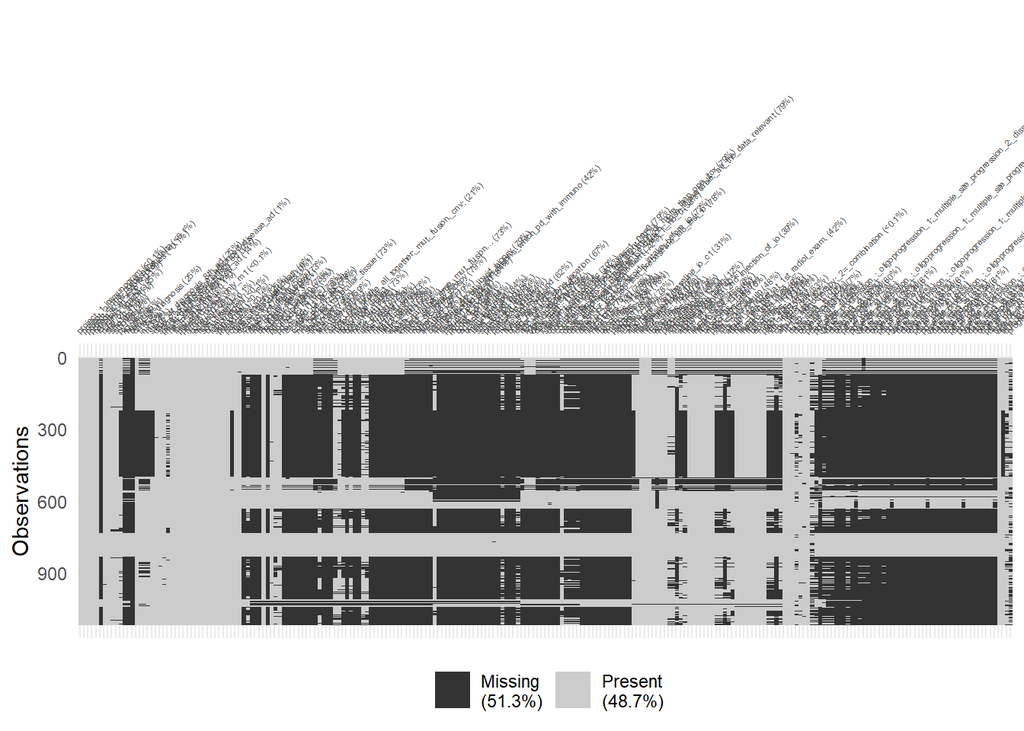

```r
vis_miss(dataset) + theme(axis.text.x = element_text(size = 4))
```

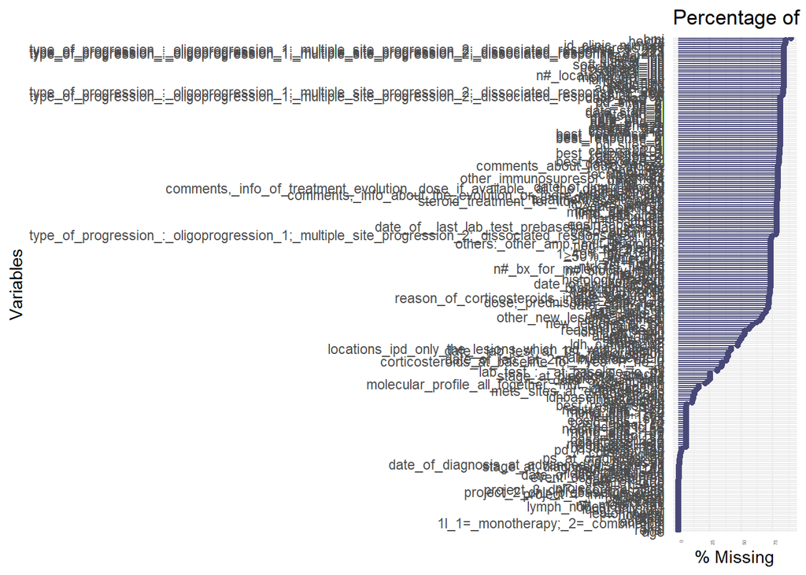

```r
#FOR COLUMNS
gg_miss_var(dataset, show_pct = TRUE) +
  labs(title = "Percentage of missing values for variable") +
  theme_minimal()+
  theme(axis.text.x = element_text(size = 3, angle = 90, hjust = 1))
```

```r
missing_values <- colSums(is.na(dataset))


missing_percentage <- (missing_values / nrow(dataset)) * 100


missing_report <- data.frame(
  column = names(dataset),
  missing_values = as.vector(missing_values),
  missing_percentage = as.vector(missing_percentage)
) %>%
  arrange(desc(missing_percentage))

num_columns_below_5 <- sum(missing_report$missing_percentage < 12)
print(paste("Number of columns with missing percentage < 12%:", num_columns_below_5))
```

```
## [1] "Number of columns with missing percentage < 12%: 65"
```

Fortunately the significant variables that we want to include in our model have all very few missing values

relevant_columns = [‘age’, ‘sex’, ‘smoking’, ‘ps_at_diagnosis_ad’, ’n#_mets_sites’, ‘lung_only_m1’, ‘pleural’, ‘pericard’,‘lymph_nodes_only_m1’,‘soft_tissue’, ‘leptomingeal’,‘skin’,‘peritoneal’,‘renal’,‘pancreas’, ‘brain’, ‘liver’, ‘bone’, ‘adrenal’, ‘histology’, ‘hbbaselineio’,‘leucotbaselineio’, ‘neut_abs…143’,‘linfo_abs…144’,‘baso_abs…145’, ‘mono_abs…147’, ‘plaqtbaselineio’,‘ldhbaselineio’,‘cprbaselineio’, ‘albumbaselineio’, ‘alk_fusion’, ‘egfr_mut’] N.B: ‘eoisn_abs’ could be useful, but since it has a higher percentage of missing value and it’s a too detailed info, here the imputation could be excessive, so we won’t include it in the models

**Possible variable response (classification): ‘pd_1l_yes=1’**

**Possible variable response (regression): ‘progression’ but with a higher % of missing values**

Drop the column (following this i should drop 149 columns, that is the 64,5%, quite high but they are all useless variables for our purpose)

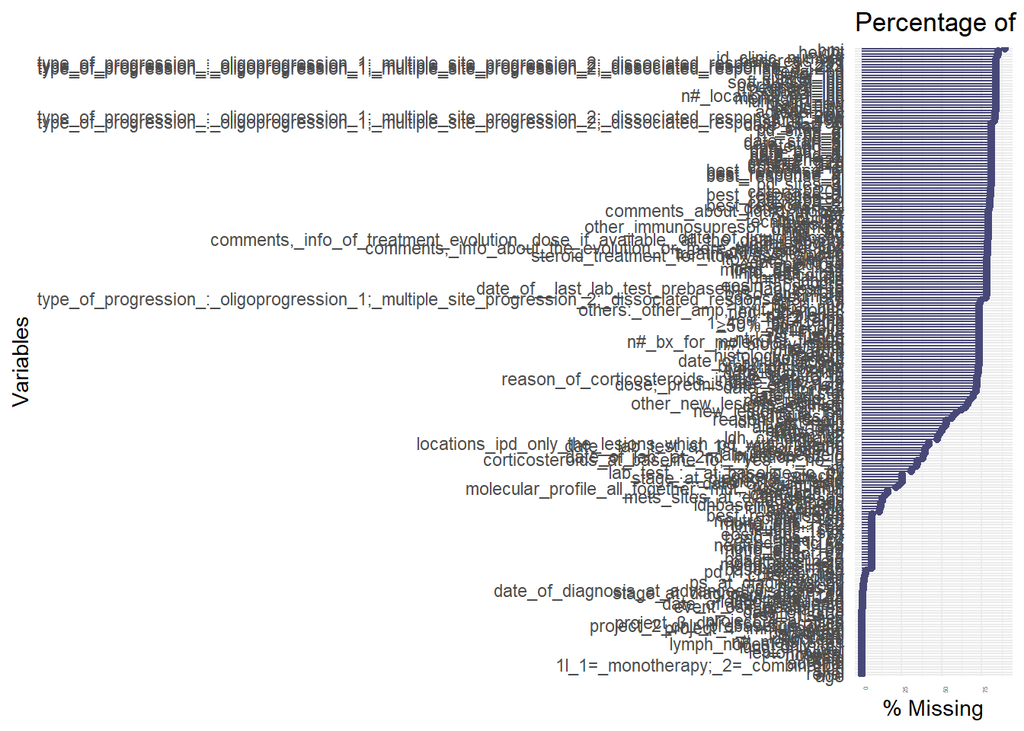

```r
#FOR COLUMNS
gg_miss_var(dataset, show_pct = TRUE) +
  labs(title = "Percentage of missing values for variable") +
  theme_minimal()+
  theme(axis.text.x = element_text(size = 3, angle = 90, hjust = 1))
```

```r
missing_values <- colSums(is.na(dataset))


missing_percentage <- (missing_values / nrow(dataset)) * 100


missing_report <- data.frame(
  column = names(dataset),
  missing_values = as.vector(missing_values),
  missing_percentage = as.vector(missing_percentage)
) %>%
  arrange(desc(missing_percentage))

num_columns_above_40 <- sum(missing_report$missing_percentage > 40)
print(paste("Number of columns with missing percentage > 40%:", num_columns_above_40))
```

```
## [1] "Number of columns with missing percentage > 40%: 149"
```

Even if we have doubt it’s obvious that the columns having a missing percentage > 80% are completely useless: we can proceed to eliminate them (they’re 59, so the 25,5% acceptable)

```r
columns_to_remove <- names(dataset)[which(missing_percentage > 80)]

dataset <- dataset %>%
  select(-all_of(columns_to_remove))
```

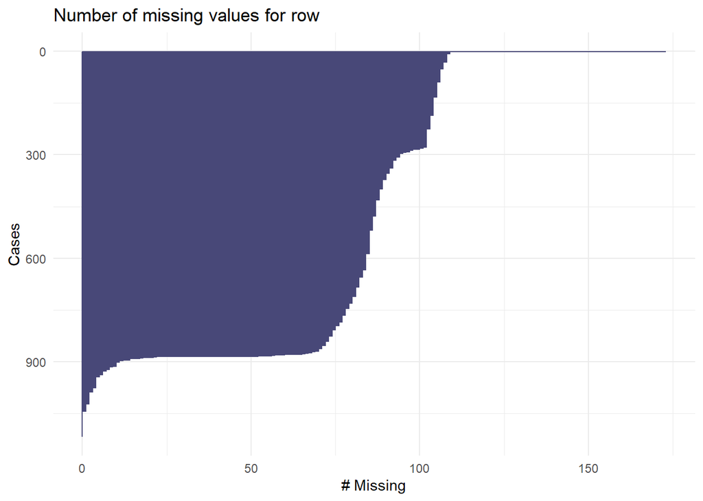

```r
# FOR ROWS
gg_miss_case(dataset) +
  labs(title = "Number of missing values for row") +
  theme_minimal()
```

```r
missing_values <- rowSums(is.na(dataset))

missing_percentage <- (missing_values / ncol(dataset)) * 100

missing_report <- data.frame(
  row = 1:nrow(dataset),
  missing_values = missing_values,
  missing_percentage = missing_percentage
) %>%
  arrange(desc(missing_percentage))

num_rows_above_50 <- sum(missing_report$missing_percentage > 50)
print(paste("Number of rows with missing percentage > 50%:", num_rows_above_50))
```

```
## [1] "Number of rows with missing percentage > 50%: 398"
```

### Rows with many NAs (>50%)

Yes but this is done to the whole dataset; however we said that we’ll focus on some specific variables (that have all less that 12% of missing values); so for the moment we skip this passage (it could be eliminate important samples that could help our models in the training)

```r
dim(dataset)
```

```
## [1] 1117  176
```

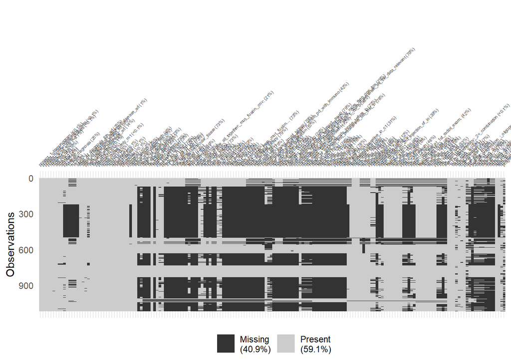

```r
vis_miss(dataset) + theme(axis.text.x = element_text(size = 4))
```

## Types of variables

```r
table(sapply(dataset, function(x) class(x)[1]))
```

```
##
## character      Date   numeric   POSIXct
##       156         6        13         1
```

### Analysis of the importan/significant variables

**AGE**

```r
class(dataset$age)
```

```
## [1] "numeric"
```

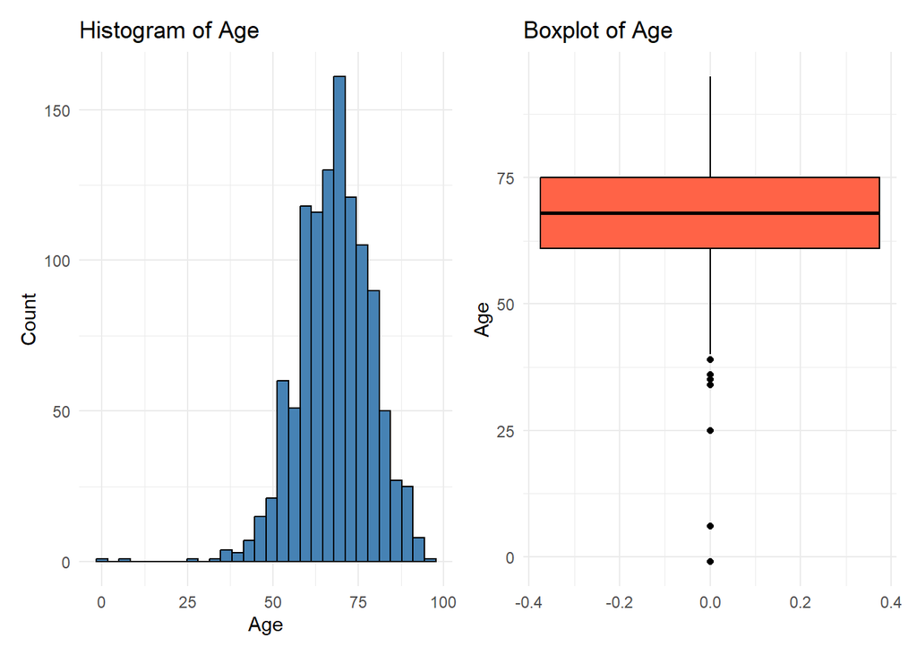

```r
# Histogram
hist_plot <- ggplot(dataset, aes(x = age)) +
  geom_histogram(fill = "steelblue", color = "black", bins = 30) +
  labs(title = "Histogram of Age", x = "Age", y = "Count") +
  theme_minimal()

# Boxplot
box_plot <- ggplot(dataset, aes(x = age)) +
  geom_boxplot(fill = "tomato", color = "black", outlier.shape = 19) +
  coord_flip() +
  labs(title = "Boxplot of Age", x = "Age", y = "") +
  theme_minimal()

hist_plot + box_plot
```

**PS AT ADVANCED DIAGNOSIS**

```r
class(dataset$ps_at_diagnosis_ad)
```

```
## [1] "numeric"
```

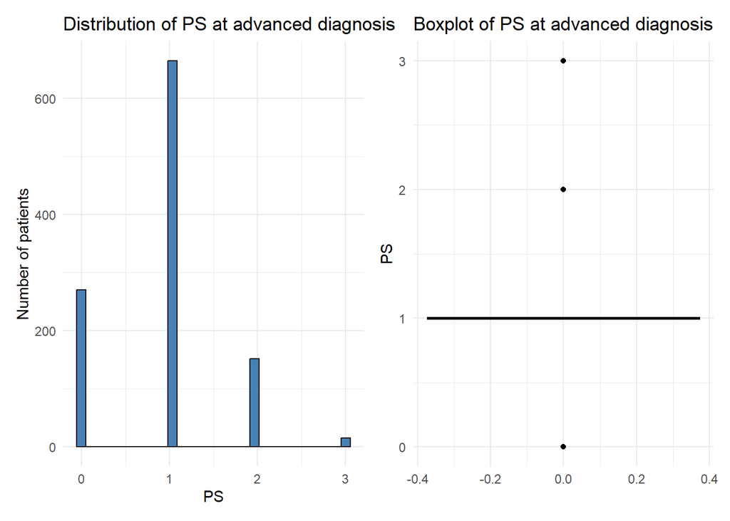

```r
# Histogram
hist_plot <- ggplot(dataset, aes(x = ps_at_diagnosis_ad)) +
  geom_histogram(fill = "steelblue", color = "black", bins = 30) +
  labs(
  title = "Distribution of PS at advanced diagnosis",
  x = "PS",
  y = "Number of patients"
)+
  theme_minimal()

# Boxplot
box_plot <- ggplot(dataset, aes(x = ps_at_diagnosis_ad)) +
  geom_boxplot(fill = "tomato", color = "black", outlier.shape = 19) +
  coord_flip() +
  labs(title = "Boxplot of PS at advanced diagnosis", x = "PS", y = "") +
  theme_minimal()

hist_plot + box_plot
```

**SMOKER**

```r
class(dataset$smoker)
```

```
## [1] "character"
```

```r
unique(dataset$smoker)
```

```
## [1] "yes" "no"  NA
```

```r
dataset <- dataset %>%
  mutate(smoker = case_when(
    smoker == "yes" ~ 1,
    smoker == "no" ~ 0,
    TRUE ~ NA_real_
  ))
```

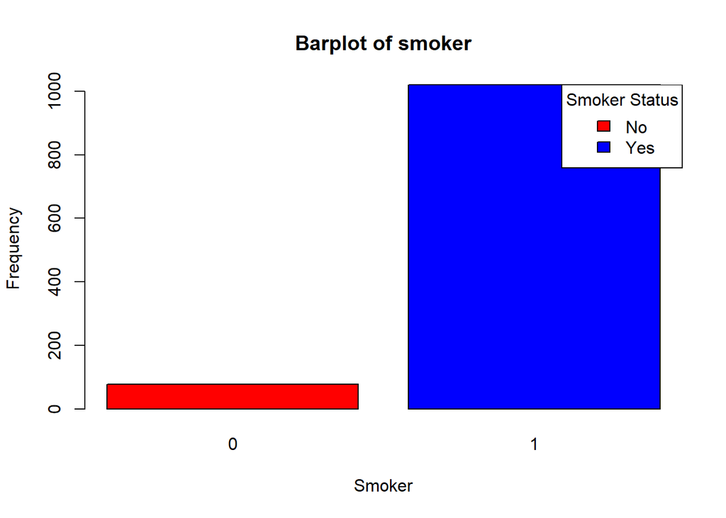

```r
counts <- table(dataset$smoker, useNA = "no")

colors <- c("red", "blue")
category_labels <- c("No", "Yes")

barplot(counts,
            col = colors,
            main = "Barplot of smoker",
            xlab = "Smoker",
            ylab = "Frequency",
            names.arg = names(counts),
            border = "black")


legend("topright",
           legend = category_labels,
           fill = colors,
           title = "Smoker Status",
           border = "black")
```

**PRESENCE OF METASTASES**

```r
vars_to_convert <- c("lung_only_m1", "pleural", "pericard", "lymph_nodes_only_m1", "soft_tissue","leptomingeal", "skin",
                     "peritoneal", "renal", "pancreas", "brain", "liver", "bone", "adrenal")
for (var in vars_to_convert) {
  #print(class(dataset[[var]]))
  #print(unique(dataset[[var]]))
}

dataset <- dataset %>%
  mutate(across(all_of(vars_to_convert), ~ case_when(
    . == "1" ~ 1,
    . == "0" ~ 0,
    TRUE ~ NA_real_
  )))
```

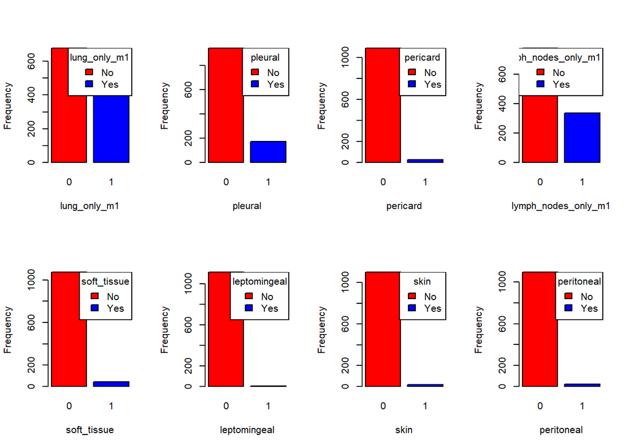

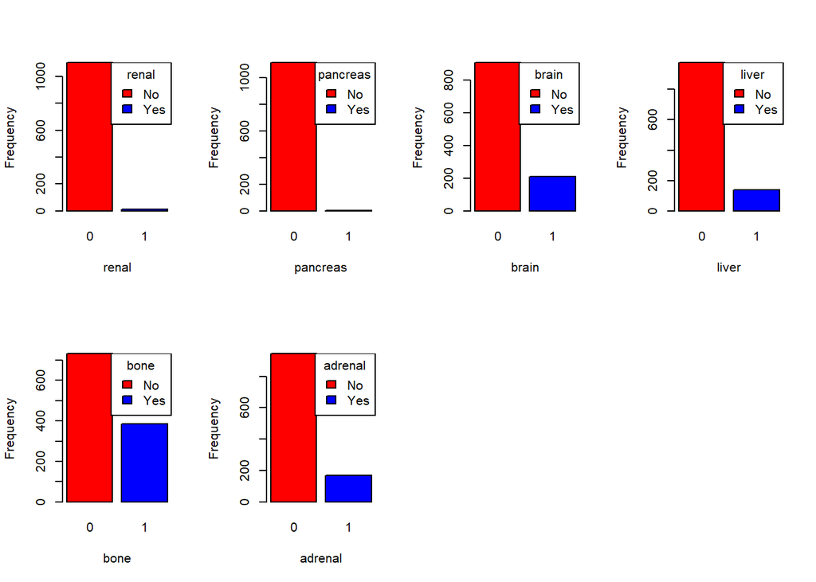

```r
par(mfrow = c(2, 4))

colors <- c("red", "blue")
category_labels <- c("No", "Yes")


for (var in vars_to_convert) {
  counts <- table(dataset[[var]], useNA = "no")

  barplot(counts,
          col = colors,
          xlab = var,
          ylab = "Frequency",
          names.arg = names(counts),
          border = "black")

  legend("topright",
         legend = category_labels,
         fill = colors,
         title = var,
         border = "black")
}
```

**SEX**

```r
class(dataset$sex)
```

```
## [1] "character"
```

```r
unique(dataset$sex)
```

```
## [1] "Male"   "Female" NA
```

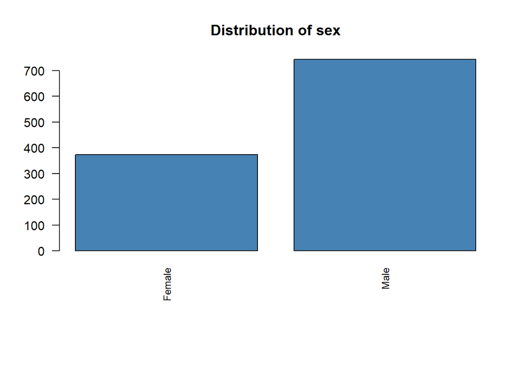

```r
par(mfrow = c(1, 1), mar = c(8, 4, 4, 2))
freq_table <- table(dataset$sex)
  barplot(freq_table,
          main = "Distribution of sex",
          col = "steelblue",
          border = "black",
          las = 2, cex.names = 0.8)
```

**SMOKING HISTORY**

```r
class(dataset$smoking)
```

```
## [1] "character"
```

```r
unique(dataset$smoking)
```

```
## [1] "former"     "current"    "NON-SMOKER" NA           "NA"
```

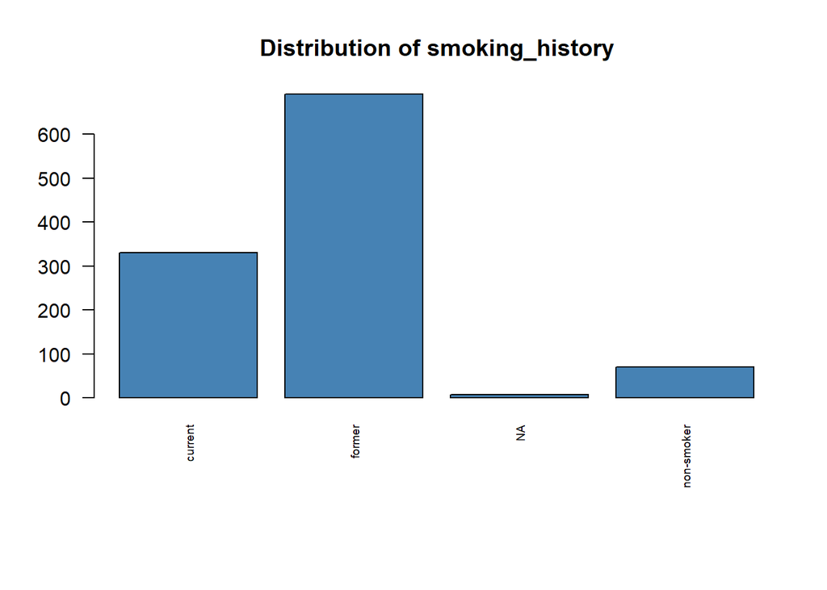

```r
dataset <- dataset %>%
  mutate(smoking = case_when(
    smoking == "NON-SMOKER" ~ "non-smoker",
    TRUE ~ smoking
  ))
par(mfrow = c(1, 1), mar = c(8, 4, 4, 2))
freq_table <- table(dataset$smoking)
  barplot(freq_table,
          main = "Distribution of smoking_history",
          col = "steelblue",
          border = "black",
          las = 2, cex.names = 0.6)
```

**HISTOLOGY**

```r
class(dataset$histology)
```

```
## [1] "character"
```

```r
unique(dataset$histology)
```

```
## [1] "ADENOCARCINOMA" "SQUAMOUS"       "NSCLC"          "Adenocarcinoma"
## [5] "Squamous"       NA               "ADENOSQUAMOUS"
```

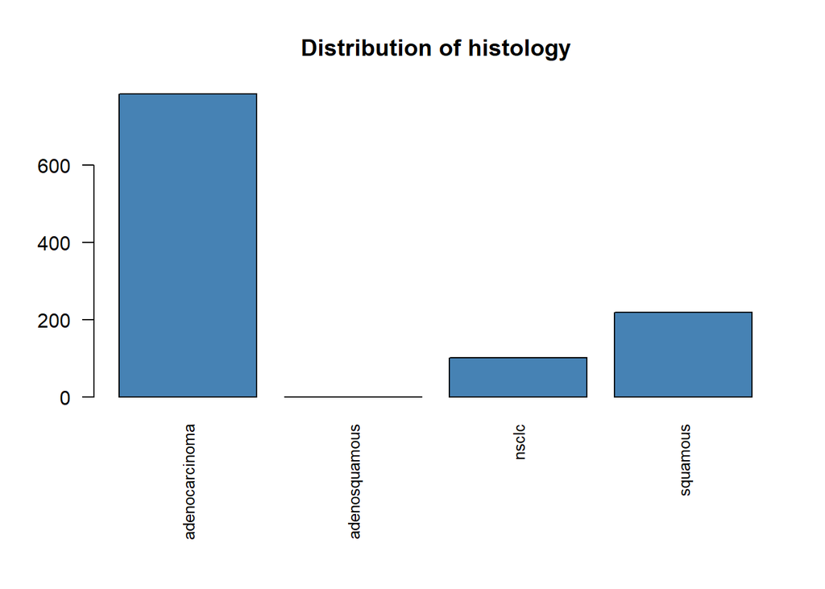

```r
dataset <- dataset %>%
  mutate(histology = tolower(histology))

par(mfrow = c(1, 1), mar = c(8, 4, 4, 2))
freq_table <- table(dataset$histology)
  barplot(freq_table,
          main = "Distribution of histology",
          col = "steelblue",
          border = "black",
          las = 2, cex.names = 0.8)
```

**NUMBER OF SITES OF THE METASTASIS**

```r
class(dataset$`n#_mets_sites`)
```

```
## [1] "character"
```

```r
unique(dataset$`n#_mets_sites`)
```

```
##  [1] "1"  "3"  "2"  "0"  "5"  "4"  "7"  "6"  "NA" "8"  NA
```

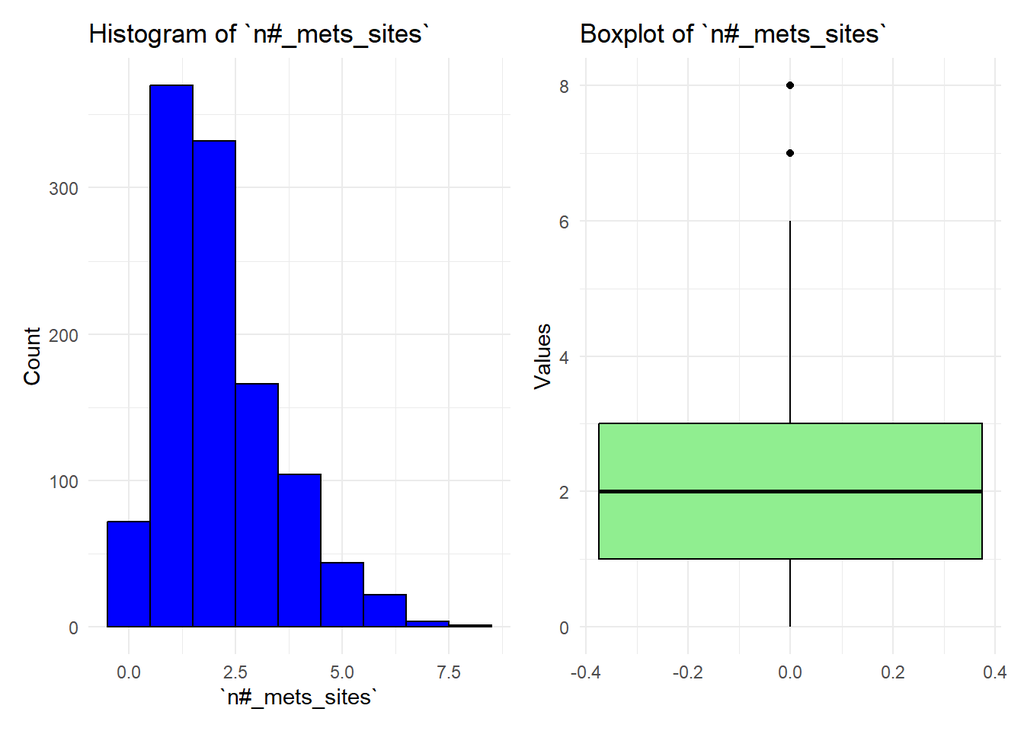

```r
dataset$`n#_mets_sites` <- as.numeric(gsub(",", ".", dataset$`n#_mets_sites`))

# Histogram
hist_plot1 <- ggplot(dataset, aes(x = `n#_mets_sites`)) +
  geom_histogram(fill = "blue", color = "black",binwidth = 1) +
  labs(title = "Histogram of `n#_mets_sites`", x = "`n#_mets_sites`", y = "Count") +
  theme_minimal()

# Boxplot
box_plot1 <- ggplot(dataset, aes(y = `n#_mets_sites`)) +
  geom_boxplot(fill = "lightgreen", color = "black", outlier.shape = 19) +
  labs(title = "Boxplot of `n#_mets_sites`", y = "Values") +
  theme_minimal()

(hist_plot1 | box_plot1)
```

**MOLECULAR PROFILE**

```r
class(dataset$egfr_mut)
```

```
## [1] "character"
```

```r
unique(dataset$egfr_mut)
```

```
## [1] "0"   "1"   "NA"  NA    "UNK"
```

```r
class(dataset$alk_fusion)
```

```
## [1] "character"
```

```r
unique(dataset$alk_fusion)
```

```
## [1] "0"   "NA"  "no"  NA    "yes" "UNK"
```

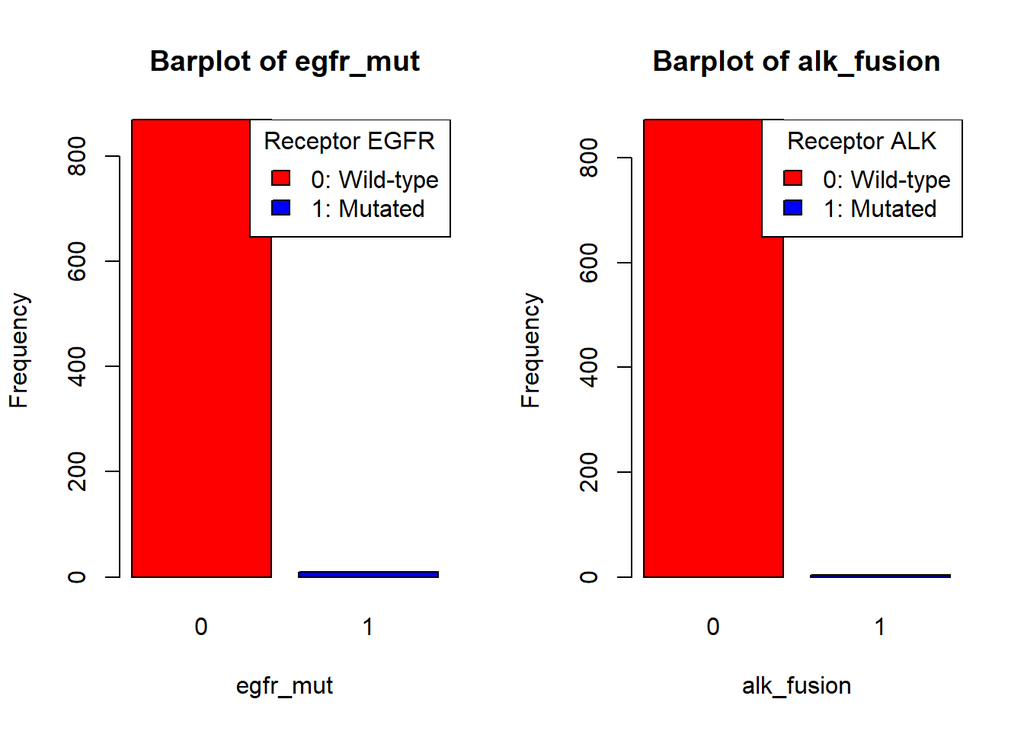

```r
dataset <- dataset %>%
  mutate(egfr_mut = case_when(
    egfr_mut == "1" ~ 1,
    egfr_mut == "0" ~ 0,
    egfr_mut %in% c("NA", "UNK") ~ NA_real_,
    TRUE ~ NA_real_
  ))

dataset <- dataset %>%
  mutate(alk_fusion = case_when(
    alk_fusion %in% c("yes") ~ 1,
    alk_fusion %in% c("no", "0") ~ 0,
    alk_fusion %in% c("NA", "UNK") ~ NA_real_,
    TRUE ~ NA_real_
  ))

mutation_vars <- list(
  egfr_mut = "EGFR",
  alk_fusion = "ALK"
)

par(mfrow = c(1,2))
colors <- c("red", "blue")
category_labels <- c("0: Wild-type", "1: Mutated")

for (var in names(mutation_vars)) {
  counts <- table(dataset[[var]], useNA = "no")

  barplot(counts,
          col = colors,
          main = paste("Barplot of", var),
          xlab = var,
          ylab = "Frequency",
          names.arg = names(counts),
          border = "black")

  legend("topright",
         legend = category_labels,
         fill = colors,
         title = paste("Receptor", mutation_vars[[var]]),
         border = "black")
}
```

```r
sum(is.na(dataset$egfr_mut))
```

```
## [1] 238
```

```r
length(dataset$egfr_mut)
```

```
## [1] 1117
```

21,3% of missing values (it’s increased since we clean the values)

```r
sum(is.na(dataset$alk_fusion))
```

```
## [1] 240
```

```r
length(dataset$alk_fusion)
```

```
## [1] 1117
```

**Baseline Hematological and Biochemical Markers**

```r
numeric_vars <- c("hbbaselineio", "leucotbaselineio", "neut_abs...143", "linfo_abs...144","baso_abs...145",
                  "mono_abs...147", "plaqtbaselineio", "ldhbaselineio", "cprbaselineio", "albumbaselineio")
for (var in numeric_vars) {
  #print(class(dataset[[var]]))
  #print(unique(dataset[[var]]))
}

dataset[numeric_vars] <- lapply(dataset[numeric_vars], function(x) {
  x_clean <- gsub(",", ".", x)
  x_clean[x_clean %in% c("UNK", "NA")] <- NA
  as.numeric(x_clean)
})
```

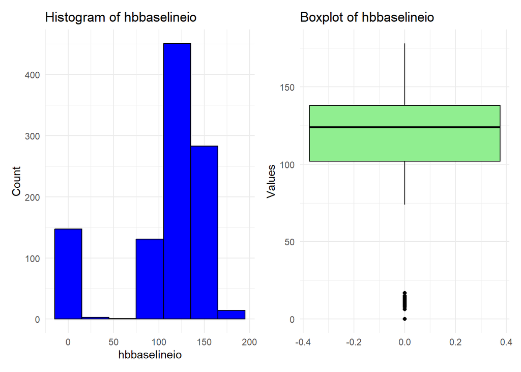

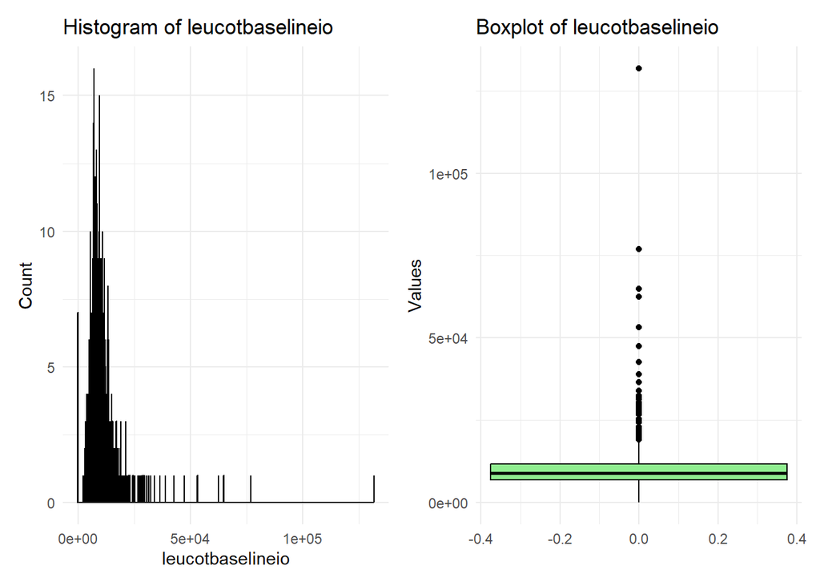

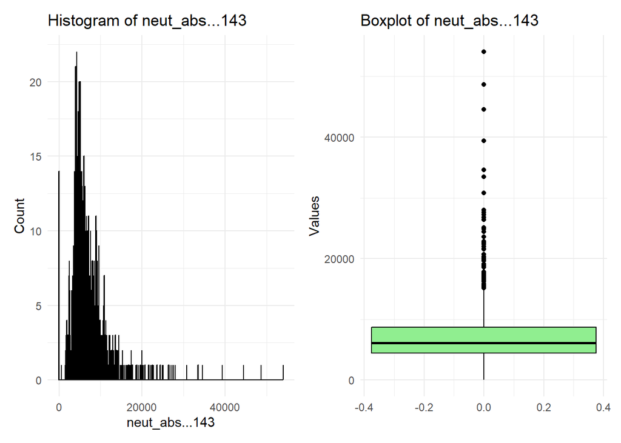

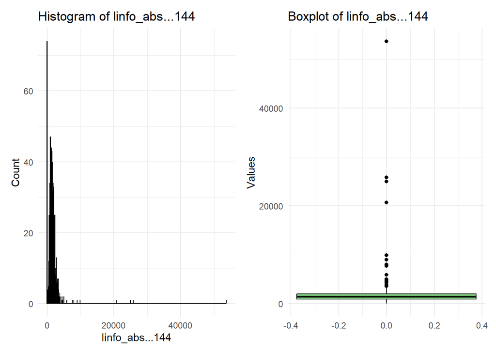

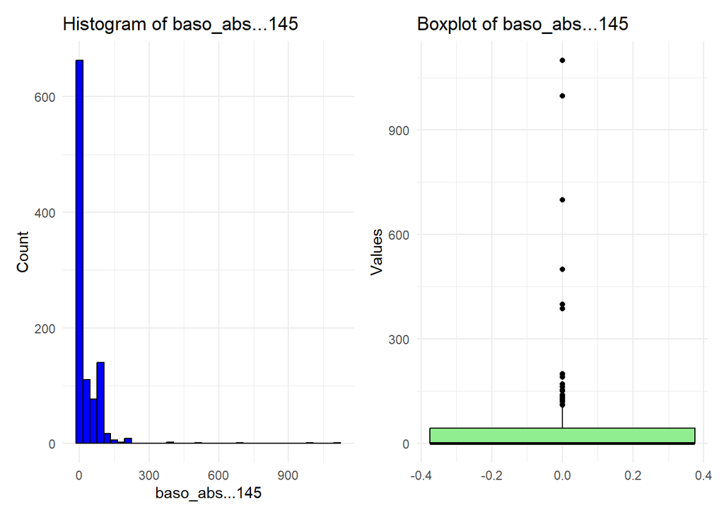

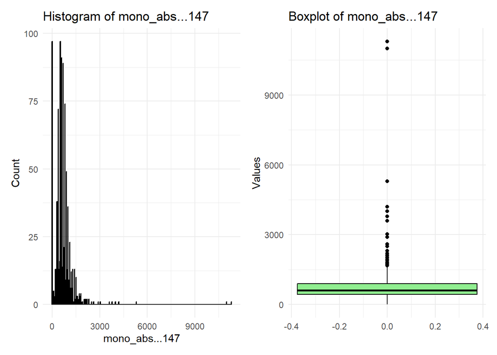

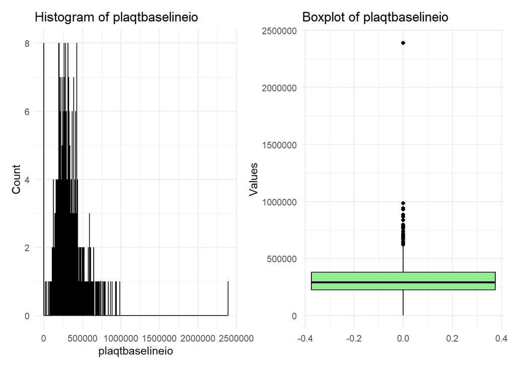

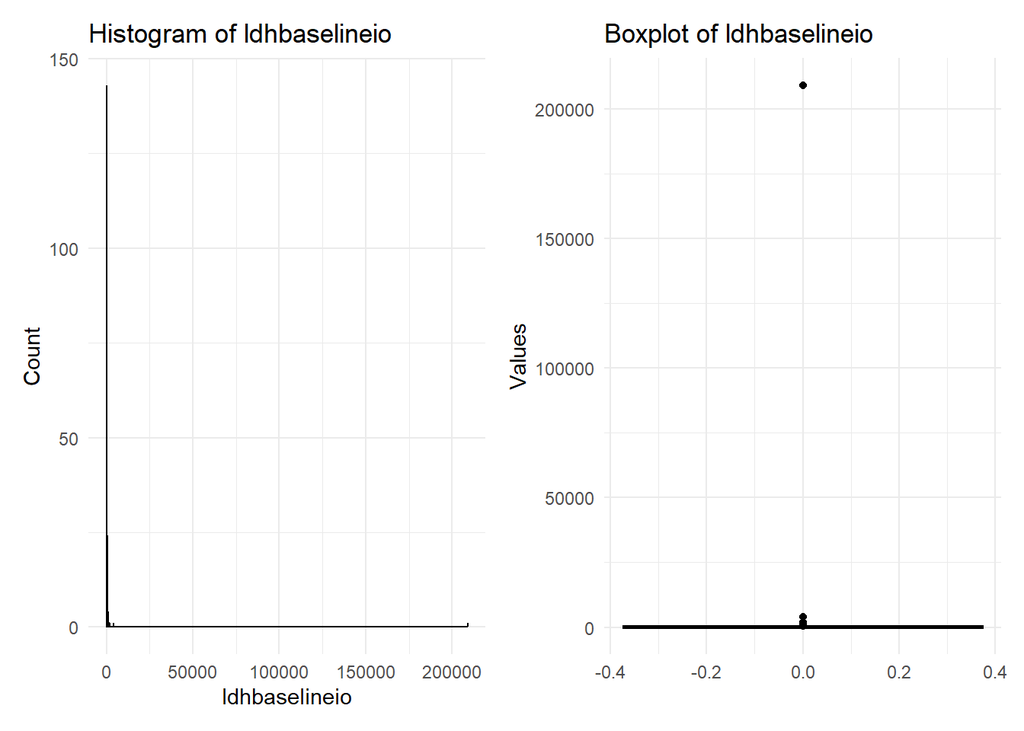

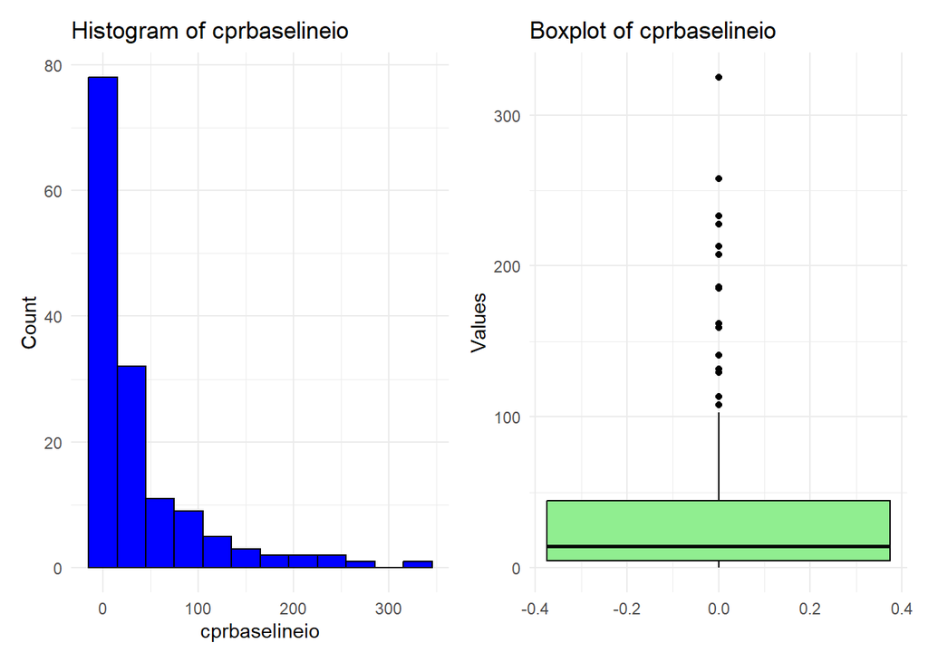

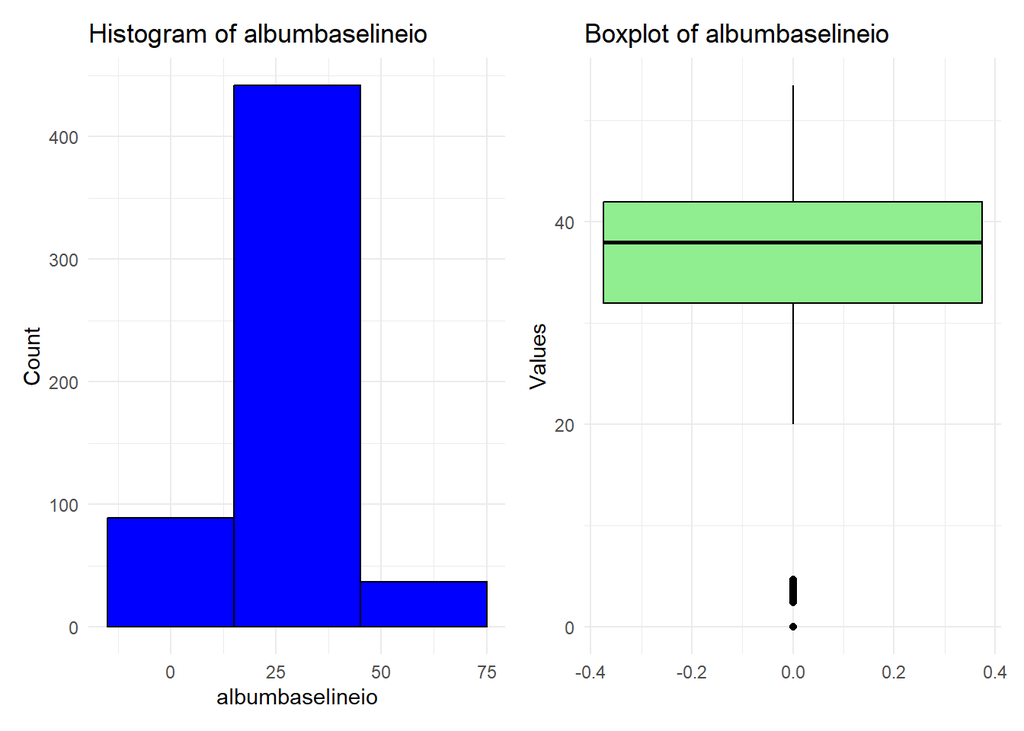

| Variable | % Missing | Decision |
| --- | --- | --- |
| hbbaselineio | 7.8% | ✅ Keep |
| leucotbaselineio | 2.1% | ✅ Keep |
| neut_abs…143 | 2.1% | ✅ Keep |
| linfo_abs…144 | 2.1% | ✅ Keep |
| baso_abs…145 | 7.8% | ✅ Keep |
| mono_abs…147 | 7.8% | ✅ Keep |
| plaqtbaselineio | 7.9% | ✅ Keep |
| ldhbaselineio | 26.4% | ❌ Discard |
| cprbaselineio | 86.9% | ❌ Discard |
| albumbaselineio | 49.1% | ❌ Discard |

```r
for (var in numeric_vars) {

  hist_plot <- ggplot(dataset, aes_string(x = var)) +
    geom_histogram(fill = "blue", color = "black", binwidth = 30) +
    labs(title = paste("Histogram of", var), x = var, y = "Count") +
    theme_minimal()

  box_plot <- ggplot(dataset, aes_string(y = var)) +
    geom_boxplot(fill = "lightgreen", color = "black", outlier.shape = 19) +
    labs(title = paste("Boxplot of", var), y = "Values") +
    theme_minimal()

  print(hist_plot | box_plot)
}
```

**TIME TO L1 START**

```r
class(dataset$time_to_l1_start)
```

```
## [1] "numeric"
```

There are case with a negative time interval: the start of the l1 is registered before the diagnosis: how can I manage these cases (even if they are only 15)?

```r
dataset %>%
  filter(!is.na(time_to_l1_start), time_to_l1_start < 0) %>%
  select(date_start_1l, progression, date_of_diagnosis, time_to_l1_start)
```

```
## # A tibble: 15 × 4
##    date_start_1l progression date_of_diagnosis time_to_l1_start
##    <date>              <dbl> <date>                       <dbl>
##  1 2021-12-31             NA 2022-11-16                    -320
##  2 2018-08-21           1393 2020-07-20                    -699
##  3 2020-11-16             NA 2022-10-17                    -700
##  4 2018-11-26             57 2019-08-16                    -263
##  5 2019-04-24             NA 2019-07-10                     -77
##  6 2017-07-28            180 2018-08-24                    -392
##  7 2016-06-14            450 2016-11-11                    -150
##  8 2017-08-22             NA 2018-07-16                    -328
##  9 2018-10-18             NA 2019-08-01                    -287
## 10 2020-08-05             20 2021-08-02                    -362
## 11 2017-03-24             NA 2018-02-01                    -314
## 12 2017-07-19             82 2017-09-01                     -44
## 13 2017-03-21            608 2017-12-01                    -255
## 14 2018-04-26             36 2019-01-26                    -275
## 15 2024-02-12             NA 2025-01-10                    -333
```

For deep analysis, we discard them for the moment

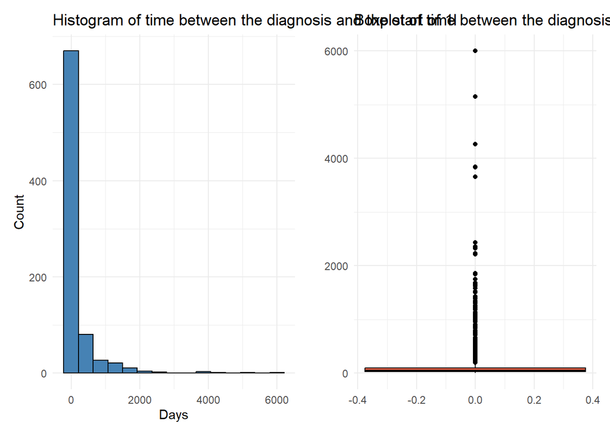

```r
# Histogram (progression > 0)
hist_plot <- ggplot(dataset %>% filter(time_to_l1_start >= 0), aes(x = time_to_l1_start)) +
  geom_histogram(fill = "steelblue", color = "black", bins = 15) +
  labs(title = "Histogram of time between the diagnosis and the start of 1l", x = "Days", y = "Count") +
  theme_minimal()

# Boxplot (progression > 0)
box_plot <- ggplot(dataset %>% filter(time_to_l1_start >= 0), aes(x = time_to_l1_start)) +
  geom_boxplot(fill = "tomato", color = "black", outlier.shape = 19) +
  coord_flip() +
  labs(title = "Boxplot of time between the diagnosis and the start of 1l", x = "", y = "") +
  theme_minimal()

hist_plot + box_plot
```

**DURATION 1L**

```r
class(dataset$duration_l1)
```

```
## [1] "numeric"
```

There are case with a negative duration: the end is registered before the start of the 1L: how can I manage these cases (even if they are only 14)?

```r
dataset %>%
  filter(!is.na(duration_l1), duration_l1 < 0) %>%
  select(date_start_1l, date_end_1l, progression, duration_l1, time_to_l1_start)
```

```
## # A tibble: 14 × 5
##    date_start_1l date_end_1l progression duration_l1 time_to_l1_start
##    <date>        <date>            <dbl>       <dbl>            <dbl>
##  1 2021-07-07    2020-10-22         -174        -258             1241
##  2 2021-02-24    2017-03-31           35       -1426              215
##  3 2019-11-15    2019-04-30          -85        -199              422
##  4 2018-02-28    2016-03-16           22        -714              212
##  5 2017-12-07    2017-12-06           87          -1              955
##  6 2018-01-29    2018-01-26           NA          -3               62
##  7 2018-07-25    2018-07-24           72          -1               27
##  8 2018-11-26    2018-11-23           NA          -3               38
##  9 2018-11-07    2018-11-06           NA          -1              357
## 10 2019-01-17    2019-01-16           NA          -1             2359
## 11 2018-07-10    2018-07-09           NA          -1               41
## 12 2018-10-25    2018-10-24           NA          -1               73
## 13 2018-05-31    2018-05-30           74          -1               57
## 14 2018-05-04    2017-09-27          165        -219             1578
```

To see the distribution, so fo analysis purposes, we discard them

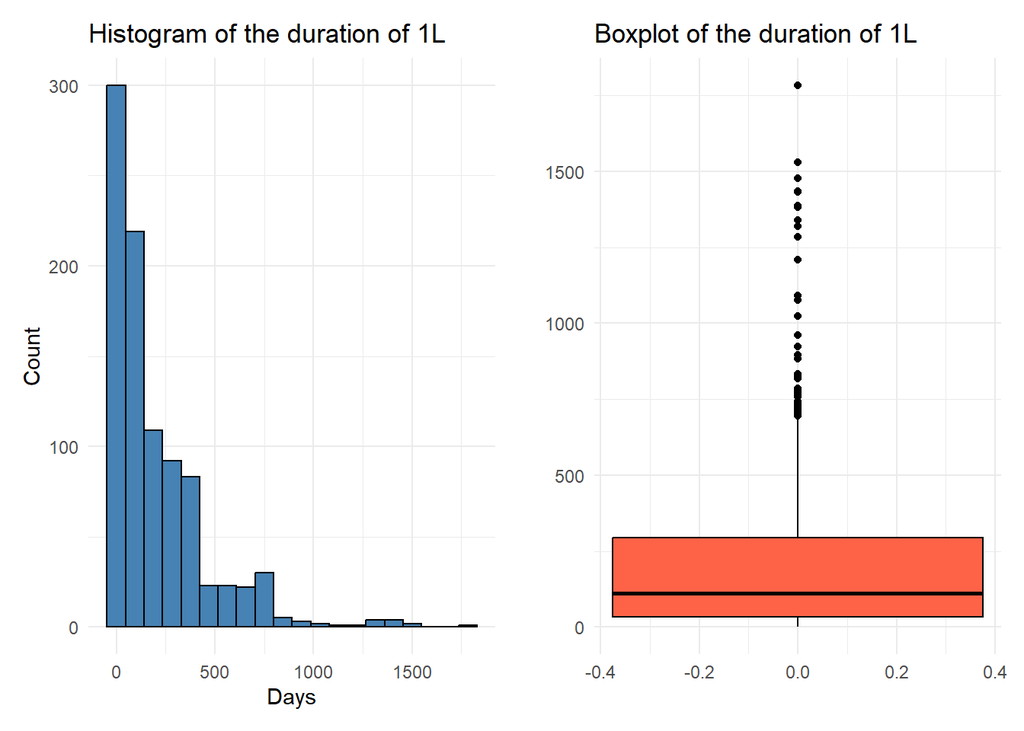

```r
# Histogram (progression > 0)
hist_plot <- ggplot(dataset %>% filter(duration_l1 >= 0), aes(x = duration_l1)) +
  geom_histogram(fill = "steelblue", color = "black", bins = 20) +
  labs(title = "Histogram of the duration of 1L", x = "Days", y = "Count") +
  theme_minimal()

# Boxplot (progression > 0)
box_plot <- ggplot(dataset %>% filter(duration_l1 >= 0), aes(x = duration_l1)) +
  geom_boxplot(fill = "tomato", color = "black", outlier.shape = 19) +
  coord_flip() +
  labs(title = "Boxplot of the duration of 1L", x = "", y = "") +
  theme_minimal()

hist_plot + box_plot
```

## Analisis of the possible response variables

**BEST RESPONSE 1L**

```r
class(dataset$best_response_1l)
```

```
## [1] "character"
```

```r
unique(dataset$best_response_1l)
```

```
##  [1] "PR"               "SD"               "PD"               "CR"
##  [5] "NE"               "RC"               "RP"               NA
##  [9] "NA"               "PE"               "PENDING"          "PARTIAL RESPONSE"
```

```r
#PE ? Is it "pending" ? but since it's very rare, we put it together with NA
dataset <- dataset %>%
  mutate(best_response_1l = case_when(
    best_response_1l == "PARTIAL RESPONSE" ~ "PR",
    best_response_1l %in% c("NA", "PENDING", "NE", "PE") ~ NA_character_,
    best_response_1l == "RP" ~ "PR",
    best_response_1l == "RC" ~ "CR",
    TRUE ~ best_response_1l
  ))
```

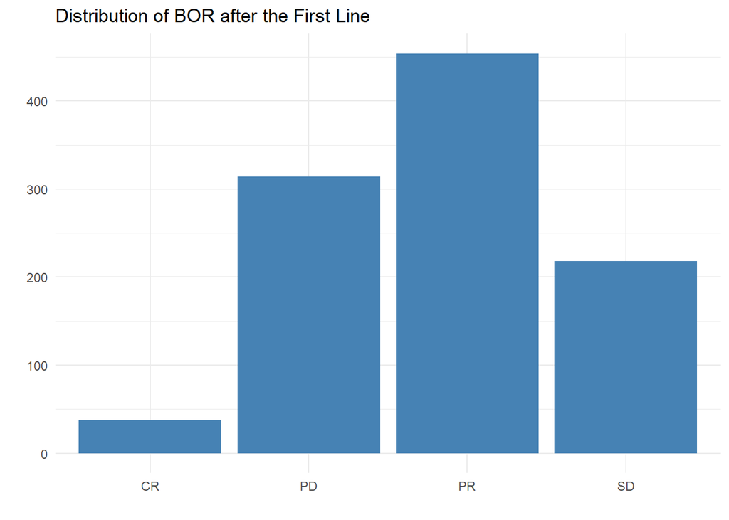

```r
ggplot(dataset[!is.na(dataset$best_response_1l), ], aes(x = best_response_1l)) +
  geom_bar(fill = "steelblue") +
  scale_x_discrete(drop = TRUE) +
  labs(title = "Distribution of BOR after the First Line",
       x = "",
       y = "") +
  theme_minimal()
```

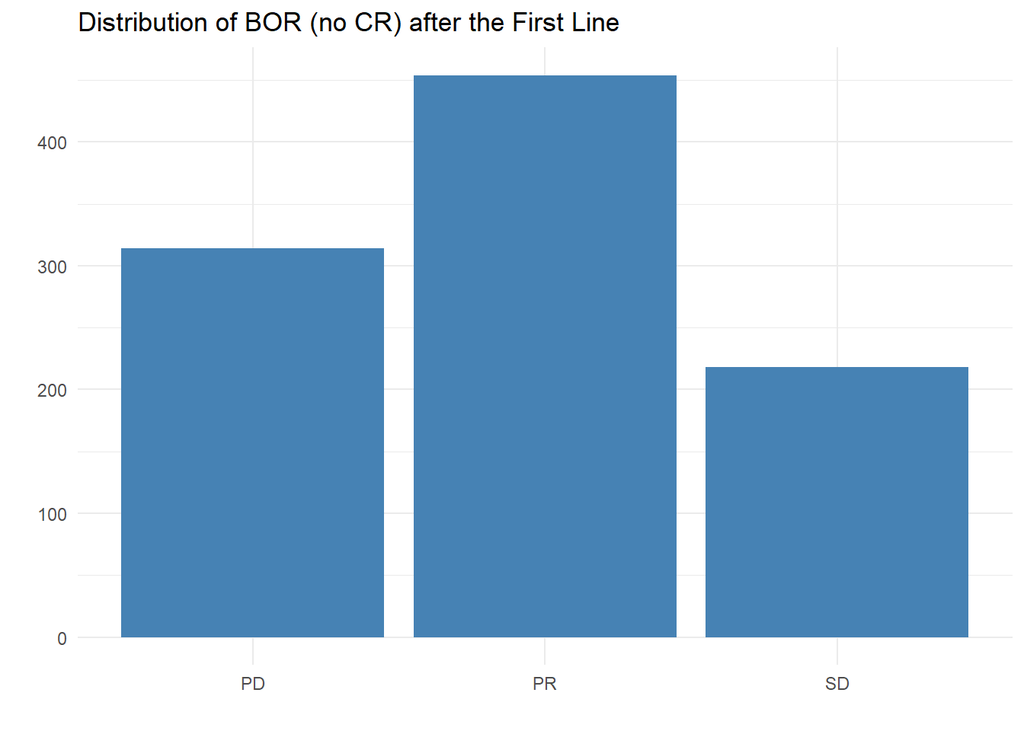

```r
dataset6 <- dataset %>%
  filter(best_response_1l != "CR")

ggplot(dataset6, aes(x = best_response_1l)) +
  geom_bar(fill = "steelblue") +
  labs(title = "Distribution of BOR (no CR) after the First Line",
       x = "",
       y = "") +
  theme_minimal()
```

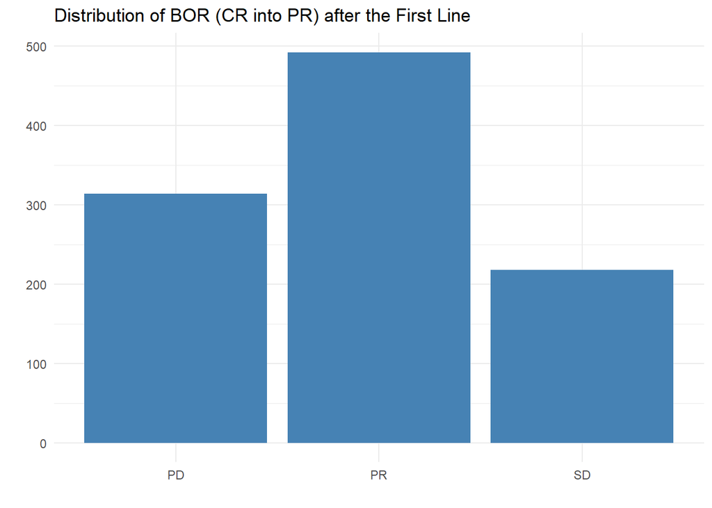

```r
dataset7 <- dataset %>%
  mutate(best_response_1l = case_when(
    best_response_1l == "CR" ~ "PR",
    TRUE ~ best_response_1l
  ))

ggplot(dataset7[!is.na(dataset$best_response_1l),], aes(x = best_response_1l)) +
  geom_bar(fill = "steelblue") +
  labs(title = "Distribution of BOR (CR into PR) after the First Line",
       x = "",
       y = "") +
  theme_minimal()
```

```r
sum(is.na(dataset$best_response_1l))
```

```
## [1] 93
```

```r
length(dataset$best_response_1l)
```

```
## [1] 1117
```

8,3%, it’s a good percentage of missing values